# Homework_3

Tianran Zhang

10/7/2019

The github repository link is: https://github.com/Creatran/Homework_3.git

# 1. Read in the data

```r
drg <- read.csv('DRG_data.csv')
#head(drg)
#names(drg)
```

# Q2

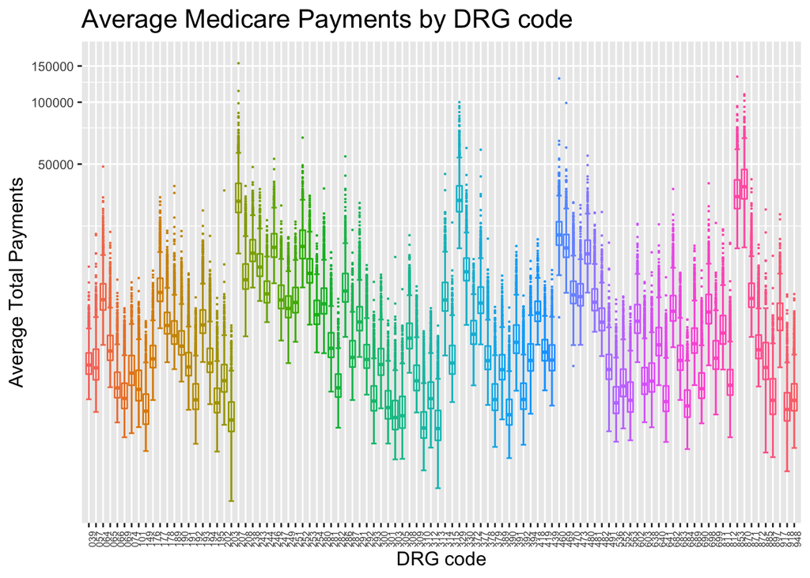

```r
drg_new <- drg %>%
  mutate(drgCode = as.factor(substr(DRG.Definition, start = 1, stop = 3)))

ggplot(data = drg_new, aes(y = Average.Medicare.Payments,  x = drgCode, col = drgCode)) +
  geom_boxplot(outlier.size = .1) +
  stat_boxplot(geom = "errorbar") +
  theme(legend.position = "none") +
  ggtitle("Average Medicare Payments by DRG code") +
  xlab("DRG code") +
  ylab("Average Total Payments") +
  coord_trans(y = 'log10') +
  #scale_y_continuous(labels = drg$DRG.Definition) +
  theme(axis.text.y = element_text(size = 8),
        axis.text.x = element_text(size = 6, angle = 90),
        axis.title = element_text(size = 12),
        plot.title = element_text(size = 16))
```

The plot shows that most hospitals have the average medicare payments lower that 50000, and have a relative large range of mediare payments. Besides, as the drg code increases, the mean of average total payments change repeatly from low to high.

# Q3

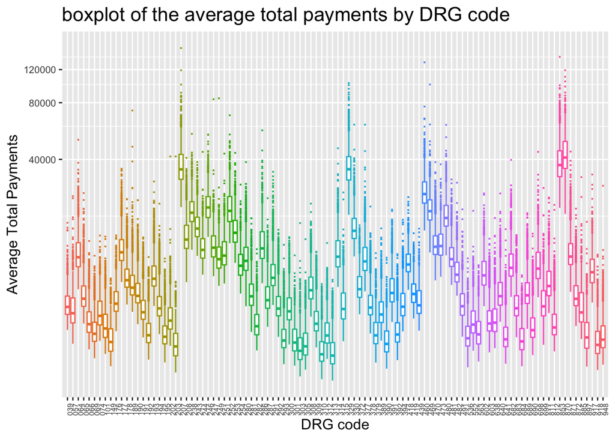

```r
ggplot(data = drg_new, aes(col = drgCode, x = drgCode, y = Average.Total.Payments,)) +
  geom_boxplot(outlier.size = .1) +
  #stat_boxplot(geom = "errorbar") +
  theme(legend.position = "none") +
  ggtitle("boxplot of the average total payments by DRG code") +
  xlab("DRG code") +
  ylab("Average Total Payments") +
  coord_trans(y = 'log10') +
  #scale_y_continuous(labels = drg$DRG.Definition) +
  theme(axis.text.y = element_text(size = 8),
        axis.text.x = element_text(size = 6, angle = 90),
        axis.title = element_text(size = 12),
        plot.title = element_text(size = 16))
```

# Q4

```r
drg_spread <- drg %>%
  select(DRG.Definition, Provider.Id, Provider.State, Average.Medicare.Payments) %>%
  spread(key = DRG.Definition, value = Average.Medicare.Payments)

#drg_spread
```

# Q5

```r
n <- ncol(drg_spread)

# For loop
calculation_for <- data.frame()
for (i in 3:ncol(drg_spread)){
  calculation_for[i - 2, 'mean'] <- mean(drg_spread[, i], na.rm = TRUE)
  calculation_for[i - 2, 'median'] <- median(drg_spread[, i], na.rm = TRUE)
  calculation_for[i - 2, 'sd'] <- sd(drg_spread[, i], na.rm = TRUE)
}
calculation_for <- calculation_for %>%
  mutate(drgCodes = names(drg_spread[3:ncol(drg_spread)]))

# find the max and min value
find_MaxMin <- function(df, varx){
  max_value <- df %>%
    arrange(desc(get(varx))) %>%
    head(1)
  min_value <- df %>%
    arrange(get(varx)) %>%
    head(1)
  #max_value <- max(df[get(varx)])
  return(bind_rows(max_value, min_value))
}

find_MaxMin(calculation_for, 'mean')
```

```
##        mean   median         sd
## 1 41899.433 38789.43 11766.8061
## 2  2876.016  2602.16   880.6649
##                                                     drgCodes
## 1           870 - SEPTICEMIA OR SEVERE SEPSIS W MV 96+ HOURS
## 2 310 - CARDIAC ARRHYTHMIA & CONDUCTION DISORDERS W/O CC/MCC
```

```r
find_MaxMin(calculation_for, 'median')
```

```
##        mean    median         sd
## 1 41899.433 38789.430 11766.8061
## 2  2879.107  2587.425   939.6978
##                                           drgCodes
## 1 870 - SEPTICEMIA OR SEVERE SEPSIS W MV 96+ HOURS
## 2                                 313 - CHEST PAIN
```

```r
find_MaxMin(calculation_for, 'sd')
```

```
##        mean   median         sd
## 1 41899.433 38789.43 11766.8061
## 2  2876.016  2602.16   880.6649
##                                                     drgCodes
## 1           870 - SEPTICEMIA OR SEVERE SEPSIS W MV 96+ HOURS
## 2 310 - CARDIAC ARRHYTHMIA & CONDUCTION DISORDERS W/O CC/MCC
```

`870 - SEPTICEMIA OR SEVERE SEPSIS W MV 96+ HOURS` has the max mean = 41899.433, max median = 38789.43, and max sd = 11766.8061, `310 - CARDIAC ARRHYTHMIA & CONDUCTION DISORDERS W/O CC/MCC` has the min mean = 2876.016, and min sd = 880.6649 `313 - CHEST PAIN` has the min median = 2587.425

# Q6

```r
# Calculate for max and min value
max_min <- function(df){
  max_df <- df[which.max(df)]
  min_df <- df[which.min(df)]
  return(c(max_df, min_df))
}

# Map
map_fun <- function(df){
  c(mean(df, na.rm = TRUE), median(df, na.rm = TRUE),
    sd(df, na.rm = TRUE))
}
calculation_map <- bind_rows(map(drg_spread[3:102], map_fun))

max_min(calculation_map[1,])
```

```
## $`870 - SEPTICEMIA OR SEVERE SEPSIS W MV 96+ HOURS`
## [1] 41899.43
##
## $`310 - CARDIAC ARRHYTHMIA & CONDUCTION DISORDERS W/O CC/MCC`
## [1] 2876.016
```

```r
max_min(calculation_map[2,])
```

```
## $`870 - SEPTICEMIA OR SEVERE SEPSIS W MV 96+ HOURS`
## [1] 38789.43
##
## $`313 - CHEST PAIN`
## [1] 2587.425
```

```r
max_min(calculation_map[3,])
```

```
## $`870 - SEPTICEMIA OR SEVERE SEPSIS W MV 96+ HOURS`
## [1] 11766.81
##
## $`310 - CARDIAC ARRHYTHMIA & CONDUCTION DISORDERS W/O CC/MCC`
## [1] 880.6649
```

```r
# Apply
calculation_apply <- data.frame(apply(drg_spread[3:102], MARGIN = 2, FUN = map_fun))

max_min(calculation_apply[1,])
```

```
## $X870...SEPTICEMIA.OR.SEVERE.SEPSIS.W.MV.96..HOURS
## [1] 41899.43
##
## $X310...CARDIAC.ARRHYTHMIA...CONDUCTION.DISORDERS.W.O.CC.MCC
## [1] 2876.016
```

```r
max_min(calculation_apply[2,])
```

```
## $X870...SEPTICEMIA.OR.SEVERE.SEPSIS.W.MV.96..HOURS
## [1] 38789.43
##
## $X313...CHEST.PAIN
## [1] 2587.425
```

```r
max_min(calculation_apply[3,])
```

```
## $X870...SEPTICEMIA.OR.SEVERE.SEPSIS.W.MV.96..HOURS
## [1] 11766.81
##
## $X310...CARDIAC.ARRHYTHMIA...CONDUCTION.DISORDERS.W.O.CC.MCC
## [1] 880.6649
```

The map and apply statement is simplier than a for loop, and they all have the same result.

# 7 NY

```r
# Find the most expensive average medicare payments
find_provider <- function(data){
  data %>%
    arrange(desc(Average.Medicare.Payments)) %>%
    select(DRG.Definition, Provider.Id, Average.Medicare.Payments) %>%
    head(1)
}

find_providers <- function(data, varx, key){
  data %>%
    filter(get(varx) == key) %>%
    group_by(Provider.State) %>%
    do(find_provider(.))
}

# find New York Providers
find_NY_Providers <- function(data1, data2){
  inner_join(data1, data2, by = c('Provider.Id', 'Provider.State', 'DRG.Definition')) %>%
  filter(Provider.State == 'NY') %>%
  select(Provider.Name)
}


providers <-
  find_providers(drg, 'DRG.Definition', '870 - SEPTICEMIA OR SEVERE SEPSIS W MV 96+ HOURS')
find_NY_Providers(drg, providers)
```

```
##                Provider.Name
## 1 WESTCHESTER MEDICAL CENTER
```

```r
k <- 5
drg$DRG.Definition[k]
```

```
## [1] 039 - EXTRACRANIAL PROCEDURES W/O CC/MCC
## 100 Levels: 039 - EXTRACRANIAL PROCEDURES W/O CC/MCC ...
```

```r
providers <-
  find_providers(drg, 'DRG.Definition', drg$DRG.Definition[k])
find_NY_Providers(drg, providers)
```

```
##                       Provider.Name
## 1 LONG ISLAND JEWISH MEDICAL CENTER
```

```r
k <- 16000
drg$DRG.Definition[k]
```

```
## [1] 177 - RESPIRATORY INFECTIONS & INFLAMMATIONS W MCC
## 100 Levels: 039 - EXTRACRANIAL PROCEDURES W/O CC/MCC ...
```

```r
providers <-
  find_providers(drg, 'DRG.Definition', drg$DRG.Definition[k])
find_NY_Providers(drg, providers)
```

```
##                Provider.Name
## 1 WESTCHESTER MEDICAL CENTER
```

The name of the most expensive provider in New York with DRG code ‘870 - SEPTICEMIA OR SEVERE SEPSIS W MV 96+ HOURS’ is WESTCHESTER MEDICAL CENTER.

The name of the most expensive provider in New York with DRG code ‘039 - EXTRACRANIAL PROCEDURES W/O CC/MCC’ is LONG ISLAND JEWISH MEDICAL CENTER.

The name of the most expensive provider in New York with DRG code ‘177 - RESPIRATORY INFECTIONS & INFLAMMATIONS W MCC’ is WESTCHESTER MEDICAL CENTER.